# Diffusion IRT for the LEVANTE mental rotation task

How to fit a Q-diffusion IRT model with diffIRT, and what its item and person parameters tell us

# 1. What the model is

Standard IRT uses only the accuracy of each response. A diffusion IRT model also uses the response time. Each response is the outcome of a noisy evidence-accumulation (Wiener) process between a correct and an incorrect boundary, which gives a joint likelihood for accuracy and response time. The **Q-diffusion** model of Molenaar, Tuerlinckx and van der Maas (2015) is meant for ability data. It splits the usual diffusion parameters into a person part and an item part:

| quantity | person | item |
| --- | --- | --- |
| boundary separation | $\gamma_p$ | $1/a_i$ |
| drift rate | $\theta_p$ | $1/v_i$ |
| non-decision time |  | $T_{er,i}$ |

so that the person-by-item boundary separation is $\gamma_p / a_i$ and the drift rate is $\theta_p / v_i$. Because the process starts midway between the boundaries, the probability of a correct response is

$$P(x_{pi}=1) =
\operatorname{logistic}\!\left(\frac{\gamma_p}{a_i}\cdot\frac{\theta_p}{v_i}\right).$$

Two things follow that matter for interpreting the parameters:

- **Larger $v_i$ means a harder item** (lower drift), so $v_i$ plays the role of difficulty.
- **Accuracy has a floor of 0.5** (as the drift goes to zero, the process becomes a coin flip). That matches the guessing parameter fixed at 0.5 in the paper’s 2PL models for this two-alternative task.

The person parameters are log-normal, $\log\gamma_p \sim N(0,\omega_\gamma^2)$ and $\log\theta_p \sim N(0,\omega_\theta^2)$, so $\theta_p$ is a person’s *speed of information accumulation* (the analogue of ability) and $\gamma_p$ is their *caution* (speed-accuracy trade-off). Both are integrated out by Gauss-Hermite quadrature, with item parameters estimated by marginal maximum likelihood.

# 2. Data

`data/mrot_rt_trial.rds` has one row per trial (run, item, correct, reaction time in seconds). diffIRT needs a persons $\times$ items matrix of responses and one of response times, with `NA` for unseen items.

```r
trials <- read_rds(here("data/mrot_rt_trial.rds"))
rt_min <- 0.5; rt_max <- 29.9

d <- trials |>
  filter(rt_s >= rt_min, rt_s < rt_max) |>
  arrange(run_id, trial_number) |>
  mutate(occ = row_number(), .by = c(run_id, item_original),
         col = paste(item_uid, item_original, occ, sep = "|"))

cols <- d |> distinct(col, item_uid, item_group) |> arrange(item_uid, col)
runs <- d |> distinct(run_id, user_id, site, dataset, adaptive, age) |> arrange(run_id)

to_mat <- \(v) d |> select(run_id, col, all_of(v)) |>
  pivot_wider(names_from = col, values_from = all_of(v)) |>
  arrange(run_id) |> select(-run_id) |> as.matrix() |> _[, cols$col]
rt <- to_mat("rt_s")
x  <- to_mat("correct"); storage.mode(x) <- "numeric"
stopifnot(identical(is.na(rt), is.na(x)))

cat(nrow(rt), "persons,", ncol(rt), "item columns,", n_distinct(cols$item_uid), "item classes;",
    sum(!is.na(rt)), "trials,", round(100 * (1 - nrow(d) / nrow(trials)), 1), "% dropped\n")
```

```
## 1158 persons, 81 item columns, 12 item classes; 49047 trials, 1.3 % dropped
```

```r
class_obs <- d |>
  summarise(n = n(), accuracy = mean(correct), mean_rt = mean(rt_s), median_rt = median(rt_s),
            .by = item_uid) |>
  arrange(item_uid)
class_obs |> mutate(across(c(accuracy, mean_rt, median_rt), f3))
```

| item_uid | n | accuracy | mean_rt | median_rt |
| --- | --- | --- | --- | --- |
| mrot_2d_duck_040 | 2898 | 0.916 | 2.897 | 2.018 |
| mrot_2d_duck_080 | 3582 | 0.872 | 3.493 | 2.422 |
| mrot_2d_duck_120 | 3989 | 0.822 | 3.530 | 2.513 |
| mrot_2d_duck_160 | 5080 | 0.774 | 4.238 | 3.075 |
| mrot_2d_rabbit_020 | 1797 | 0.945 | 2.988 | 2.249 |
| mrot_2d_rabbit_040 | 3424 | 0.935 | 3.115 | 2.175 |
| mrot_2d_rabbit_080 | 3230 | 0.887 | 3.645 | 2.608 |
| mrot_2d_rabbit_120 | 4002 | 0.814 | 3.682 | 2.685 |
| mrot_2d_rabbit_160 | 5141 | 0.755 | 4.360 | 3.183 |
| mrot_3d_shape_040 | 5650 | 0.782 | 5.684 | 4.417 |

[output cut: 2 more lines]

Accuracy falls and response time rises with the rotation angle, and the 3D shapes are much slower than the 2D animals.

# 3. Fitting the model

## Constraints

`diffIRT(rt, x, model, constrain, start, se, control)` takes a `constrain` vector of length $3 n_{items}+2$ giving, for each column, which parameter it uses: first the $a$’s, then the $v$’s, then the $T_{er}$’s, then the two scale parameters $\omega_\gamma$ and $\omega_\theta$. Columns with the same integer share a parameter, ids must run consecutively from 1, and 0 means *fixed* (at the value in `start`). Sharing parameters within an item class is therefore just a matter of building the vector:

```r
cls <- cols$item_uid
nit <- ncol(rt)
k   <- as.integer(factor(cls))      # item class of each column (1..12)
nc  <- max(k)

# non-decision time shared within 2D and within 3D classes (see below)
kt  <- as.integer(factor(grepl("_3d_", cls)))
nt  <- max(kt)

constrain <- c(k,                       # a_i: one per class
               nc + k,                  # v_i: one per class
               2 * nc + kt,             # Ter: one per 2D/3D group
               2 * nc + nt + 1,         # omega_gamma
               2 * nc + nt + 2)         # omega_theta
length(constrain) == 3 * nit + 2
```

```
## [1] TRUE
```

```r
max(constrain)                          # number of free parameters
```

```
## [1] 28
```

## The fit

The optimiser runs once for each number of quadrature points in `nq`, restarting from the previous solution, so `c(7, 15)` is a cheap coarse fit followed by a finer one. `se = TRUE` gives standard errors from the numerical Hessian.

```r
fit_time <- system.time(
  fit <- diffIRT(rt, x, model = "Q", constrain = constrain, se = TRUE,
                 control = list(nq = c(7, 15), trace = 0))
)
```

```
## Fitting the Q-diffusion IRT model. Please wait . . .
```

```r
c(elapsed_s = unname(fit_time["elapsed"]), converged = fit$conv == 0, minus2LL = fit$totLL,
  n_par = fit$npars, AIC = fit$AIC, BIC = fit$BIC)
```

```
##  elapsed_s  converged   minus2LL      n_par        AIC        BIC
##      4.036      1.000 253390.919     28.000 253446.919 253588.444
```

This is the optimised build of diffIRT (branch `fast-kernel`, commit `7968a61`). The same fit with the original package did not finish a 70-person subset in 20 minutes; see `README.md`.

## Is 0.3 s sensible?

Fixing $T_{er}$ at a grid of values (same data, same model) gives a profile with a minimum near 0.3 s, so the data support the fitted value:

```r
prof <- tibble(ter = c(0.1, 0.2, 0.3, 0.4)) |>
  mutate(file = here("models", sprintf("diffirt_q_rtmin0.5_fast_nall_nq7-15_terfixed%s.rds", ter)),
         minus2LL = map_dbl(file, \(f) if (file.exists(f)) read_rds(f)$fit$totLL else NA_real_)) |>
  select(-file)
prof <- bind_rows(prof, tibble(ter = NA, minus2LL = fit$totLL)) |>
  mutate(model = c(rep("Ter fixed", 4), "Ter free (2D/3D)"), .before = 1)
prof
```

| model | ter | minus2LL |
| --- | --- | --- |
| Ter fixed | 0.1 | 255249.0 |
| Ter fixed | 0.2 | 254243.3 |
| Ter fixed | 0.3 | 253794.9 |
| Ter fixed | 0.4 | 254655.9 |
| Ter free (2D/3D) | NA | 253390.9 |

# 4. Item parameters

```r
first <- match(1:nc, k)
items <- tibble(
  item_uid = levels(factor(cls)),
  a = fit$par[first],           a_se = fit$std.err[first],
  v = fit$par[nit + first],     v_se = fit$std.err[nit + first],
  ter = fit$par[2 * nit + first], ter_se = fit$std.err[2 * nit + first]) |>
  separate(item_uid, c(NA, "type", "stimulus", "angle"), sep = "_", remove = FALSE, convert = TRUE) |>
  mutate(label = paste(type, stimulus, angle), type = toupper(type))
omega <- tibble(parameter = c("omega_gamma", "omega_theta"), estimate = tail(fit$par, 2), se = tail(fit$std.err, 2))
items |> select(item_uid, a, a_se, v, v_se, ter, ter_se) |> mutate(across(-item_uid, f3))
```

| item_uid | a | a_se | v | v_se | ter | ter_se |
| --- | --- | --- | --- | --- | --- | --- |
| mrot_2d_duck_040 | 0.224 | 0.003 | 1.209 | 0.029 | 0.354 | 0.004 |
| mrot_2d_duck_080 | 0.217 | 0.002 | 1.488 | 0.036 | 0.354 | 0.004 |
| mrot_2d_duck_120 | 0.226 | 0.002 | 1.892 | 0.048 | 0.354 | 0.004 |
| mrot_2d_duck_160 | 0.220 | 0.002 | 2.915 | 0.073 | 0.354 | 0.004 |
| mrot_2d_rabbit_020 | 0.225 | 0.003 | 1.394 | 0.038 | 0.354 | 0.004 |
| mrot_2d_rabbit_040 | 0.216 | 0.003 | 1.294 | 0.031 | 0.354 | 0.004 |
| mrot_2d_rabbit_080 | 0.209 | 0.002 | 1.621 | 0.041 | 0.354 | 0.004 |
| mrot_2d_rabbit_120 | 0.224 | 0.002 | 2.231 | 0.054 | 0.354 | 0.004 |
| mrot_2d_rabbit_160 | 0.223 | 0.002 | 3.415 | 0.094 | 0.354 | 0.004 |
| mrot_3d_shape_040 | 0.194 | 0.002 | 5.751 | 0.161 | 0.155 | 0.011 |

[output cut: 2 more lines]

```r
omega |> mutate(across(-parameter, f3))
```

| parameter | estimate | se |
| --- | --- | --- |
| omega_gamma | 0.230 | 0.005 |
| omega_theta | 0.641 | 0.011 |

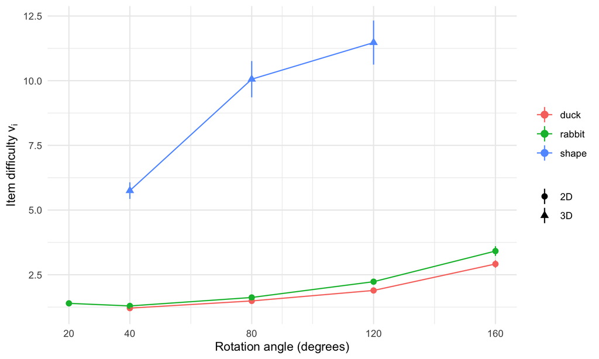

```r
ggplot(items, aes(angle, v, colour = stimulus, shape = type)) +
  geom_pointrange(aes(ymin = v - 2 * v_se, ymax = v + 2 * v_se)) +
  geom_line() +
  scale_x_continuous(breaks = unique(items$angle)) +
  labs(x = "Rotation angle (degrees)", y = expression(paste("Item difficulty ", v[i])), colour = NULL, shape = NULL)
```

# 5. Comparison with the paper’s 2PL item estimates

The paper fits a multigroup 2PL (guessing fixed at 0.5, scalar invariance across datasets) with the same twelve item classes. The coefficients are in `models/mrot_coef.rds`. In `mirt`’s parameterisation $P = g + (1-g)\,\mathrm{logistic}(a_1\theta + d)$, with difficulty $b=-d/a_1$.

```r
irt <- read_rds(here("models/mrot_coef.rds")) |>
  filter(model_set == "multigroup_dataset", subset == "all_items", itemtype == "2pl", invariance == "scalar") |>
  distinct(item_uid = item, a1, d, b = difficulty, g)
cmp <- items |> left_join(irt, by = "item_uid") |>
  mutate(av = a * v,                       # product enters the Q-model logit as theta*gamma / (a*v)
         slope_q = 1 / (a * v))           # change in logit per unit of gamma*theta
stopifnot(!anyNA(cmp$b))
cmp |> select(item_uid, `2PL b` = b, `2PL a1` = a1, `Q: v` = v, `Q: a` = a, `Q: a*v` = av) |>
  mutate(across(-item_uid, f3))
```

| item_uid | 2PL b | 2PL a1 | Q: v | Q: a | Q: a*v |
| --- | --- | --- | --- | --- | --- |
| mrot_2d_duck_040 | -2.600 | 1.604 | 1.209 | 0.224 | 0.270 |
| mrot_2d_duck_080 | -2.076 | 1.622 | 1.488 | 0.217 | 0.323 |
| mrot_2d_duck_120 | -1.522 | 1.971 | 1.892 | 0.226 | 0.427 |
| mrot_2d_duck_160 | -0.739 | 2.575 | 2.915 | 0.220 | 0.642 |
| mrot_2d_rabbit_020 | -3.736 | 1.106 | 1.394 | 0.225 | 0.313 |
| mrot_2d_rabbit_040 | -2.994 | 1.460 | 1.294 | 0.216 | 0.279 |
| mrot_2d_rabbit_080 | -2.382 | 1.441 | 1.621 | 0.209 | 0.340 |
| mrot_2d_rabbit_120 | -1.381 | 1.677 | 2.231 | 0.224 | 0.500 |
| mrot_2d_rabbit_160 | -0.605 | 2.549 | 3.415 | 0.223 | 0.763 |
| mrot_3d_shape_040 | -0.078 | 1.182 | 5.751 | 0.194 | 1.116 |

[output cut: 2 more lines]

## Correlations across the 12 classes

In the Q model the logit is $(\gamma_p\theta_p)/(a_i v_i)$, so the product $a_i v_i$ is the item’s overall hardness, and its reciprocal is the item’s *slope* relative to the person’s speed. Difficulty and discrimination are therefore tied together in a way they are not in the 2PL: a larger $v_i$ lowers accuracy and also flattens the item’s response to $\theta$.

```r
cor_tab <- function(x, y, label) tibble(
  comparison = label,
  pearson  = cor(x, y), spearman = cor(x, y, method = "spearman"))
bind_rows(
  cor_tab(cmp$b,  log(cmp$v),         "2PL difficulty b vs log v"),
  cor_tab(cmp$b,  log(cmp$av),        "2PL difficulty b vs log(a*v)"),
  cor_tab(cmp$b,  cmp$ter,            "2PL difficulty b vs Ter"),
  cor_tab(cmp$a1, cmp$slope_q,        "2PL discrimination a1 vs Q slope 1/(a*v)"),
  cor_tab(cmp$a1, cmp$a,              "2PL discrimination a1 vs Q boundary a"),
  cor_tab(cmp$a1, log(cmp$v),         "2PL discrimination a1 vs log v")) |>
  mutate(across(-comparison, \(z) round(z, 2)))
```

| comparison | pearson | spearman |
| --- | --- | --- |
| 2PL difficulty b vs log v | 0.96 | 0.97 |
| 2PL difficulty b vs log(a*v) | 0.96 | 0.97 |
| 2PL difficulty b vs Ter | -0.80 | -0.75 |
| 2PL discrimination a1 vs Q slope 1/(a*v) | -0.35 | -0.45 |
| 2PL discrimination a1 vs Q boundary a | 0.22 | 0.13 |
| 2PL discrimination a1 vs log v | 0.19 | 0.45 |

The difficulty-like parameter lines up very closely with the 2PL difficulty: $r = .96$ over the 12 classes. The 2D/3D gap drives part of that, so the within-2D values below matter, and they are still high. Non-decision time is also lower for the harder (3D) classes, but with only two estimated values ($T_{er}$ is shared within 2D and within 3D) that correlation carries no information. Discrimination does not match: across all classes the 2PL $a_1$ is weakly and *negatively* related to the Q slope $1/(a_i v_i)$, and within the 2D classes the sign is clearly opposite, because 2PL slopes rise with angle while the Q-model slope falls as $v_i$ rises.

```r
two <- filter(cmp, type == "2D")
c(`within 2D (n = 9): b vs log v` = cor(two$b, log(two$v)),
  `within 2D: b vs log(a*v)`     = cor(two$b, log(two$av)),
  `within 2D: a1 vs 1/(a*v)`     = cor(two$a1, two$slope_q),
  `within 2D: a1 vs log v`       = cor(two$a1, log(two$v))) |> round(2)
```

```
## within 2D (n = 9): b vs log v      within 2D: b vs log(a*v)
##                          0.89                          0.89
##      within 2D: a1 vs 1/(a*v)        within 2D: a1 vs log v
##                         -0.84                          0.87
```

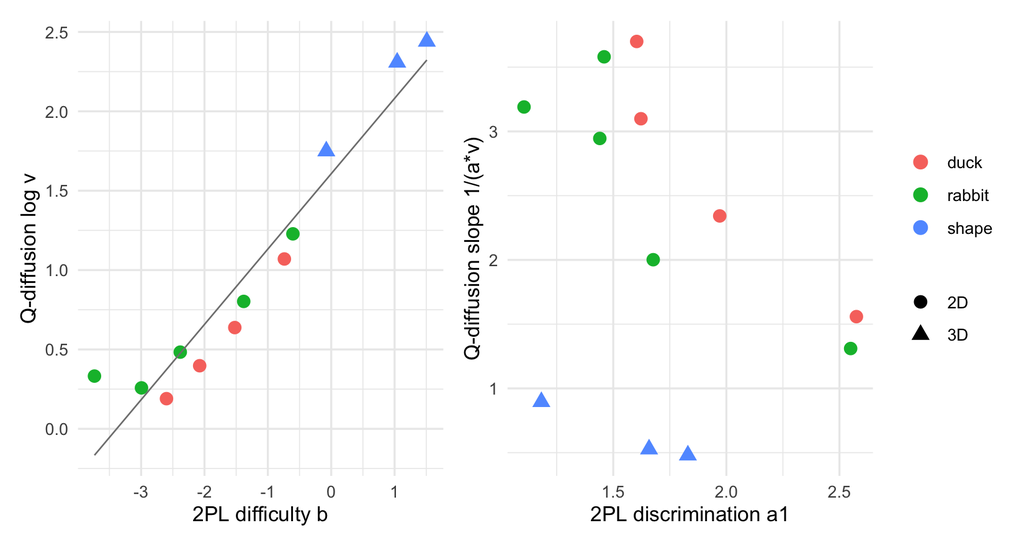

```r
p1 <- ggplot(cmp, aes(b, log(v), colour = stimulus, shape = type)) +
  geom_point(size = 3) + geom_smooth(aes(group = 1), method = "lm", se = FALSE, colour = "grey50", linewidth = .4) +
  labs(x = "2PL difficulty b", y = "Q-diffusion log v", colour = NULL, shape = NULL)
p2 <- ggplot(cmp, aes(a1, slope_q, colour = stimulus, shape = type)) +
  geom_point(size = 3) +
  labs(x = "2PL discrimination a1", y = "Q-diffusion slope 1/(a*v)", colour = NULL, shape = NULL)
patchwork::wrap_plots(p1, p2, guides = "collect")
```

## Predicted accuracy and response time

The parameters are not on the same scale, so compare what they predict. For each person with both scores, compute the probability of a correct response to each item class from (i) the 2PL with the paper’s $\hat\theta$ and (ii) the Q-diffusion model with the person’s own $(\hat\gamma_p,\hat\theta_p)$ from `factest()`, and compare both with the observed accuracy. The scores are the same persons’ EAP estimates, so both models are evaluated in-sample.

```r
sc <- factest(fit)                     # EAP gamma (col 1) and theta (col 2) for each person
persons <- bind_cols(runs, tibble(gamma = sc[, 1], theta = sc[, 2])) |>
  left_join(read_rds(here("models/mrot_scores.rds")) |> filter(model_set == "multigroup_dataset") |>
              select(run_id, theta_irt = metric_value), by = "run_id")
colSums(is.na(persons[c("gamma", "theta", "theta_irt")]))
```

```
##     gamma     theta theta_irt
##         0         0         0
```

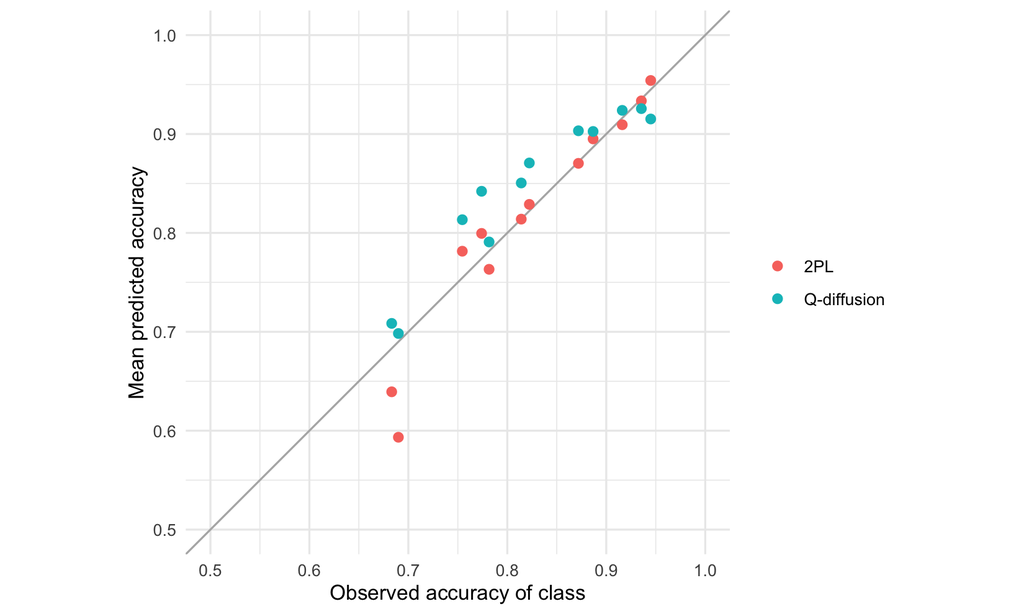

```r
pred <- d |>
  select(run_id, item_uid, correct, rt_s) |>
  left_join(persons |> select(run_id, gamma, theta, theta_irt), by = "run_id") |>
  left_join(cmp |> select(item_uid, a, v, ter, a1, d, g), by = "item_uid") |>
  mutate(p_2pl = g + (1 - g) * plogis(a1 * theta_irt + d),
         A  = gamma / a,                        # person x item boundary separation
         nu = theta / v,                        # person x item drift rate
         p_q = plogis(A * nu),
         # mean RT of the Wiener process starting midway: Ter + A/(2 nu) * tanh(A nu / 2)
         rt_q = ter + ifelse(abs(nu) < 1e-8, A^2 / 4, A / (2 * nu) * tanh(A * nu / 2)))

by_class <- pred |>
  summarise(observed = mean(correct), `2PL` = mean(p_2pl, na.rm = TRUE), `Q-diffusion` = mean(p_q),
            .by = item_uid) |>
  pivot_longer(-c(item_uid, observed), names_to = "model", values_to = "predicted")
ggplot(by_class, aes(observed, predicted, colour = model)) +
  geom_abline(colour = "grey70") + geom_point(size = 2) +
  coord_equal(xlim = c(.5, 1), ylim = c(.5, 1)) +
  labs(x = "Observed accuracy of class", y = "Mean predicted accuracy", colour = NULL)
```

```r
fit_stats <- pred |> filter(!is.na(p_2pl)) |>
  summarise(across(c(p_2pl, p_q), list(
    brier = \(p) mean((correct - p)^2),
    logloss = \(p) -mean(correct * log(p) + (1 - correct) * log(1 - p))), .names = "{.col}_{.fn}"))
fit_stats |> pivot_longer(everything(), names_to = c("model", "stat"), names_pattern = "p_(.*)_(.*)") |>
  pivot_wider(names_from = stat, values_from = value) |>
  mutate(model = recode(model, `2pl` = "2PL", q = "Q-diffusion"), across(-model, \(z) round(z, 4)))
```

| model | brier | logloss |
| --- | --- | --- |
| 2PL | 0.1266 | 0.3855 |
| Q-diffusion | 0.1326 | 0.4037 |

The 2PL predicts accuracy a little better (Brier 0.127 vs 0.133, log loss 0.386 vs 0.404). That is expected: it is fit to accuracy alone, whereas the Q-diffusion model also has to account for the response times and gives up a little accuracy fit to do so. The 2PL cannot predict response times at all. The model-implied mean response time can be checked per class. Plug-in scores compress person variance, so these predictions are rough: they are close for the 2D classes (within about 0.15 s) and about 0.3–0.4 s too slow for the 3D classes.

```r
pred |> summarise(`observed mean RT (s)` = mean(rt_s), `predicted mean RT (s)` = mean(rt_q), .by = item_uid) |>
  arrange(item_uid) |> mutate(across(-item_uid, \(z) round(z, 2)))
```

| item_uid | observed mean RT (s) | predicted mean RT (s) |
| --- | --- | --- |
| mrot_2d_duck_040 | 2.90 | 2.85 |
| mrot_2d_duck_080 | 3.49 | 3.35 |
| mrot_2d_duck_120 | 3.53 | 3.46 |
| mrot_2d_duck_160 | 4.24 | 4.19 |
| mrot_2d_rabbit_020 | 2.99 | 3.08 |
| mrot_2d_rabbit_040 | 3.12 | 3.12 |
| mrot_2d_rabbit_080 | 3.65 | 3.64 |
| mrot_2d_rabbit_120 | 3.68 | 3.73 |
| mrot_2d_rabbit_160 | 4.36 | 4.42 |
| mrot_3d_shape_040 | 5.68 | 6.05 |

[output cut: 2 more lines]

# 6. Person parameters

```r
persons |> summarise(across(c(gamma, theta, theta_irt, age), list(mean = mean, sd = sd), na.rm = TRUE)) |>
  pivot_longer(everything(), names_to = c("variable", "stat"), names_pattern = "(.*)_(mean|sd)") |>
  pivot_wider(names_from = stat) |> mutate(across(-variable, f3))
```

| variable | mean | sd |
| --- | --- | --- |
| gamma | 1.045 | 0.228 |
| theta | 1.292 | 0.816 |
| theta_irt | -0.562 | 1.477 |
| age | 9.394 | 2.164 |

## Relation to the paper’s ability score and to age

```r
persons |> select(`Q: theta (speed of accumulation)` = theta, `Q: gamma (caution)` = gamma,
                  `2PL theta` = theta_irt, age) |>
  cor(use = "pairwise", method = "spearman") |> round(2)
```

```
##                                  Q: theta (speed of accumulation)
## Q: theta (speed of accumulation)                             1.00
## Q: gamma (caution)                                           0.35
## 2PL theta                                                    0.87
## age                                                          0.43
##                                  Q: gamma (caution) 2PL theta  age
## Q: theta (speed of accumulation)               0.35      0.87 0.43
## Q: gamma (caution)                             1.00      0.56 0.02
## 2PL theta                                      0.56      1.00 0.35
## age                                            0.02      0.35 1.00
```

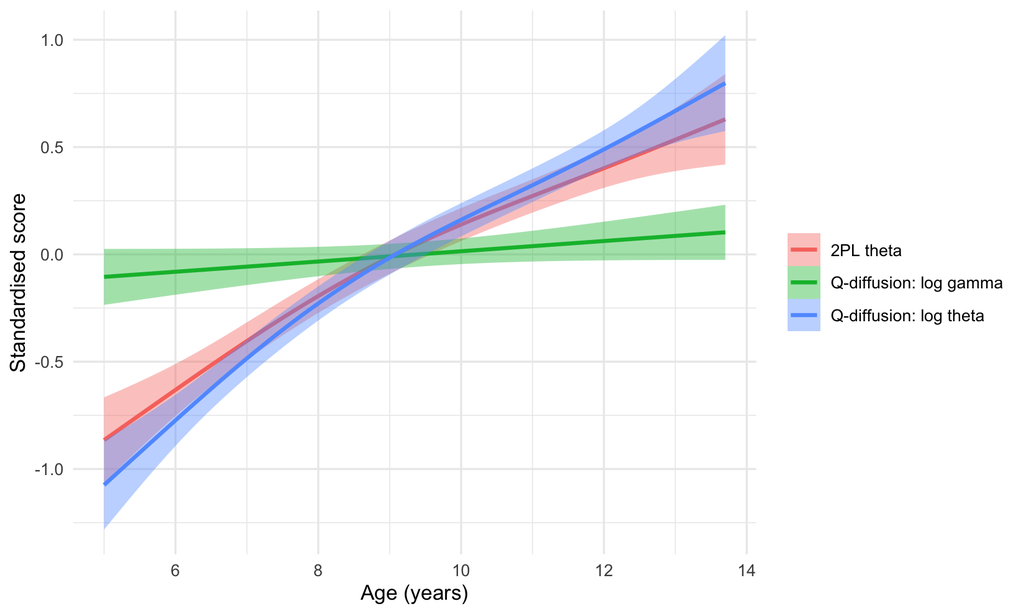

```r
long <- persons |>
  mutate(`Q-diffusion: log theta` = log(theta), `Q-diffusion: log gamma` = log(gamma), `2PL theta` = theta_irt) |>
  pivot_longer(c(`Q-diffusion: log theta`, `Q-diffusion: log gamma`, `2PL theta`), names_to = "score") |>
  group_by(score) |> mutate(z = as.numeric(scale(value))) |> ungroup()
ggplot(long, aes(age, z, colour = score, fill = score)) +
  geom_smooth(method = "gam", formula = y ~ s(x, k = 5)) +
  labs(x = "Age (years)", y = "Standardised score", colour = NULL, fill = NULL)
```

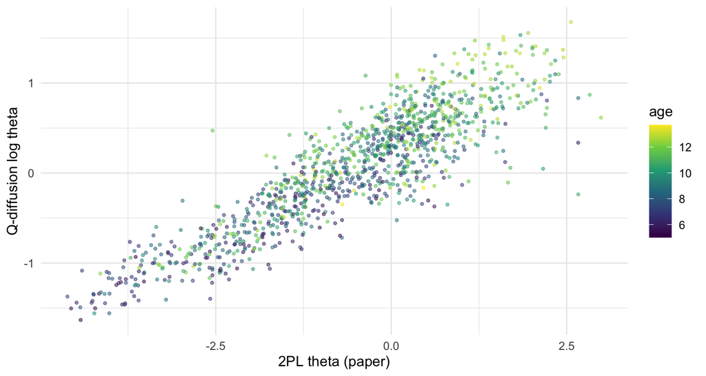

```r
ggplot(persons, aes(theta_irt, log(theta), colour = age)) + geom_point(alpha = .5, size = .8) +
  scale_colour_viridis_c() + labs(x = "2PL theta (paper)", y = "Q-diffusion log theta")
```

Drift rate $\theta$ tracks the paper’s ability scores (Spearman .87) and increases with age (.43, against .35 for the 2PL score). The boundary parameter $\gamma$ is unrelated to age (.02), so the age gain here comes from faster accumulation of evidence rather than from a shift in the speed-accuracy trade-off. $\gamma$ also correlates positively with ability (.35 with $\theta$, .56 with the 2PL score). Section 7 shows that $\gamma$ is mostly an overall response-speed parameter: it correlates .89 with a run’s mean log RT. Read it as the *level* of the child’s response times (slow, careful responders have a high $\gamma$), not as a clean caution trait.

## Differences between datasets

```r
persons |> summarise(n = n(), age = mean(age), `2PL theta` = mean(theta_irt, na.rm = TRUE),
                      `log theta` = mean(log(theta)), `log gamma` = mean(log(gamma)), .by = dataset) |>
  mutate(across(-c(dataset, n), \(z) round(z, 2)))
```

| dataset | n | age | 2PL theta | log theta | log gamma |
| --- | --- | --- | --- | --- | --- |
| mpieva-de | 403 | 9.13 | 0.14 | 0.34 | 0.10 |
| uniandes-co-rural | 324 | 9.75 | -1.24 | -0.23 | -0.01 |
| western-ca | 194 | 8.88 | -0.56 | 0.08 | -0.05 |
| uniandes-co-bogota | 237 | 9.79 | -0.83 | -0.05 | -0.03 |

```r
# Dataset order of log theta matches the 2PL ordering (mpieva-de > western-ca > bogota > rural); log gamma differs little.
# How much of each score does age explain (spline in age)?
r2 <- \(y) summary(lm(y ~ splines::ns(age, 3), data = persons))$r.squared
c(`2PL theta` = r2(persons$theta_irt), `Q: log theta` = r2(log(persons$theta)), `Q: log gamma` = r2(log(persons$gamma))) |> round(3)
```

```
##    2PL theta Q: log theta Q: log gamma
##        0.134        0.198        0.003
```

# 7. Do the paper’s age, sex and site results replicate with the diffusion scores?

`05_diffirt_paper_analyses.R` runs the paper’s ability model, `score ~ age * sex * site + (1 | user_id)` with sex sum-coded and average marginal effects over the observed runs, on five scores: the 2PL $\theta$, the diffusion $\log\theta$ and $\log\gamma$, and, as descriptive anchors, each run’s accuracy and mean log RT. Effects are in SD units of each score. The model is fit on the 929 runs the paper uses for this analysis. The 2PL row reproduces the paper (age 0.33 per year in raw units = 0.23 SD; sex difference 0.00, $p$ = .998).

```r
pr <- read_rds(here("models/diffirt_paper_results.rds"))
pr$effects |>
  filter(effect %in% c("age (per year)", "sex (Male - Female)", "age slope: Male - Female")) |>
  transmute(measure, effect, est = sprintf("%.3f (%.3f)%s", estimate_sd, se_sd, ifelse(p < .05, "*", ""))) |>
  pivot_wider(names_from = effect, values_from = est)
```

| measure | age (per year) | sex (Male - Female) | age slope: Male - Female |
| --- | --- | --- | --- |
| 2PL theta | 0.227 (0.014)* | -0.000 (0.056) | -0.024 (0.028) |
| Diffusion log theta (drift) | 0.256 (0.013)* | 0.073 (0.054) | 0.012 (0.027) |
| Diffusion log gamma (boundary) | 0.060 (0.016)* | -0.134 (0.064)* | -0.025 (0.031) |
| Accuracy | 0.195 (0.015)* | 0.017 (0.061) | -0.002 (0.030) |
| Mean log RT | 0.004 (0.016) | -0.167 (0.064)* | -0.043 (0.032) |

(`*` = $p < .05$, uncorrected for the five scores.)

- **Age.** Drift $\log\theta$ grows by 0.26 SD per year, close to the 2PL value of 0.23. The age $\times$ sex interaction is null for every score. $\log\gamma$ has only a small age trend (0.06 SD per year) and mean log RT none, so the age gain is carried by $\theta$.
- **Sex.** There is no sex difference in 2PL ability or in drift $\theta$ (boys +0.07 SD, $p$ = .18), and none in accuracy. Boys have lower $\gamma$ (−0.13 SD, $p$ = .035) and shorter mean log RT (−0.17 SD, $p$ = .009). This matches the paper’s finding that boys are faster but not more accurate, and it puts the speed difference in the boundary/response-level parameter, not in ability. The $\gamma$ result is nominal ($p$ = .035 among five scores), and $\gamma$ is highly correlated with mean log RT (Spearman .89 across runs), so it adds little beyond the RT result itself.

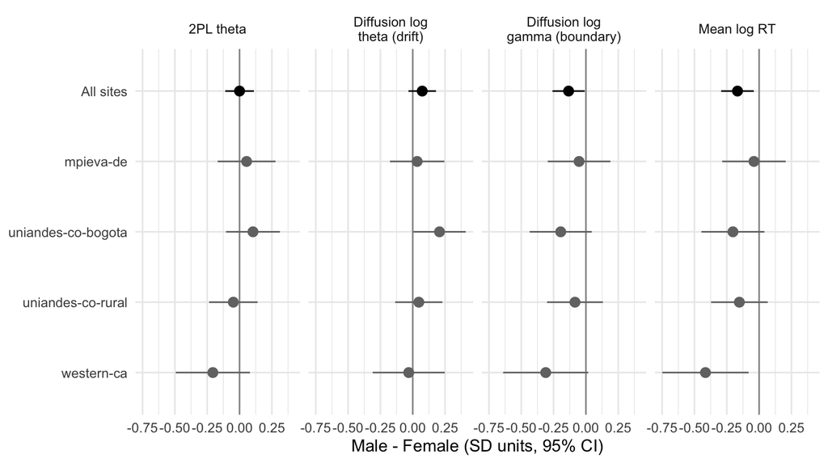

```r
pr$effects |>
  filter(startsWith(effect, "sex within") | effect == "sex (Male - Female)",
         measure %in% c("2PL theta", "Diffusion log theta (drift)", "Diffusion log gamma (boundary)", "Mean log RT")) |>
  mutate(where = ifelse(effect == "sex (Male - Female)", "All sites", sub("sex within ", "", effect)),
         where = factor(where, levels = rev(c("All sites", "mpieva-de", "uniandes-co-bogota", "uniandes-co-rural", "western-ca"))),
         measure = factor(measure, levels = c("2PL theta", "Diffusion log theta (drift)", "Diffusion log gamma (boundary)", "Mean log RT"))) |>
  ggplot(aes(estimate_sd, where, colour = where == "All sites")) +
  geom_vline(xintercept = 0, colour = "grey60") +
  geom_pointrange(aes(xmin = estimate_sd - 1.96 * se_sd, xmax = estimate_sd + 1.96 * se_sd)) +
  facet_wrap(~measure, nrow = 1, labeller = label_wrap_gen(18)) +
  scale_colour_manual(values = c(`TRUE` = "black", `FALSE` = "grey45"), guide = "none") +
  labs(x = "Male - Female (SD units, 95% CI)", y = NULL)
```

Sex differences by site are small and imprecise for every score. Drift shows a nominally positive male difference in Bogotá (+0.21 SD, SE 0.10) that the 2PL does not (+0.10, SE 0.11). With 16 site-by-score estimates this is not distinguishable from noise.

```r
sites <- pr$effects |> filter(startsWith(effect, "site:")) |>
  filter(measure %in% c("2PL theta", "Diffusion log theta (drift)", "Diffusion log gamma (boundary)", "Mean log RT")) |>
  mutate(contrast = sub("site: ", "", effect))
sites |> select(measure, contrast, estimate_sd) |> pivot_wider(names_from = measure, values_from = estimate_sd) |>
  mutate(across(where(is.numeric), \(z) round(z, 2)))
```

| contrast | 2PL theta | Diffusion log theta (drift) | Diffusion log gamma (boundary) | Mean log RT |
| --- | --- | --- | --- | --- |
| uniandes-co-bogota - mpieva-de | -0.82 | -0.79 | -0.60 | -0.45 |
| uniandes-co-rural - mpieva-de | -1.20 | -1.10 | -0.62 | -0.28 |
| uniandes-co-rural - uniandes-co-bogota | -0.38 | -0.32 | -0.01 | 0.17 |
| western-ca - mpieva-de | -0.31 | -0.25 | -0.57 | -0.45 |
| western-ca - uniandes-co-bogota | 0.51 | 0.53 | 0.03 | 0.00 |
| western-ca - uniandes-co-rural | 0.89 | 0.85 | 0.04 | -0.17 |

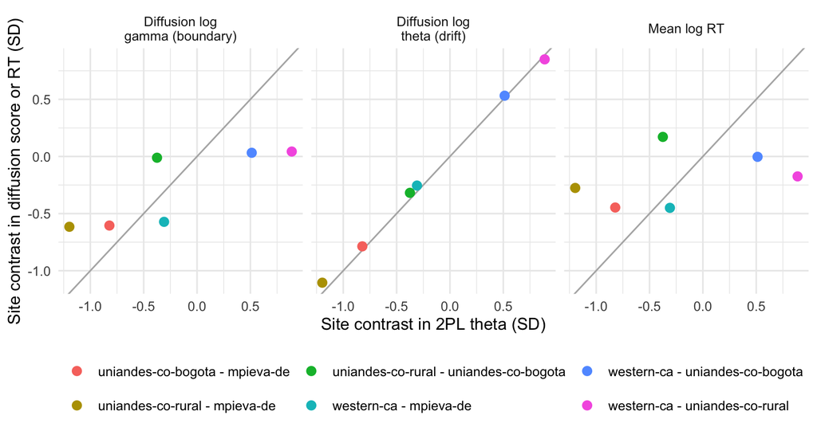

```r
ggplot(sites |> filter(measure != "2PL theta") |>
         left_join(sites |> filter(measure == "2PL theta") |> select(contrast, theta_2pl = estimate_sd), by = "contrast"),
       aes(theta_2pl, estimate_sd, colour = contrast)) +
  geom_abline(colour = "grey70") + geom_point(size = 2.5) +
  facet_wrap(~measure, nrow = 1, labeller = label_wrap_gen(18)) +
  labs(x = "Site contrast in 2PL theta (SD)", y = "Site contrast in diffusion score or RT (SD)", colour = NULL) +
  theme(legend.position = "bottom")
```

- **Sites.** The drift contrasts are almost identical to the 2PL contrasts (for example Bogotá − Leipzig −0.79 vs −0.82 SD; rural − Leipzig −1.10 vs −1.20 SD), so the site ordering is unchanged. $\log\gamma$ and mean log RT instead separate Leipzig (mpieva-de, remote home testing) from the other three sites, which fits the paper’s account of slower baseline RTs there. The model therefore puts the site difference in RT level into $\gamma$, not into drift, so $\theta$ is not inflated or deflated by the slow-RT site. The paper does not interpret site differences in ability, and this does not change that.
- **Repeated runs.** The random-intercept model reaches a conditional $R^2$ of 0.822 for the 2PL and 0.694 for drift $\theta$ (marginal 0.357 vs 0.382). The difference is the user-level share, which comes from a small group of children with more than one run. Treat it as a hint that drift is less stable across runs, not as a result.

# 8. Q or D? The additive variant

The D-diffusion model replaces the multiplicative person-by-item drift with an additive one, as in the Rasch/2PL: $\mathrm{logit}\,P = (\gamma_p/a_i)(\theta_p - v_i)$, with $\theta_p$ normal and $v_i$ a difficulty on the same scale as $\theta_p$. In this model $1/a_i$ is a discrimination-like slope that is separate from the difficulty, which the Q model does not allow. It needs no new code: the same `constrain` vector, with `model = "D"`.

```r
fit_d_time <- system.time(
  fit_d <- diffIRT(rt, x, model = "D", constrain = constrain, se = TRUE, control = list(nq = c(7, 15), trace = 0))
)
```

```
## Fitting the D-diffusion IRT model. Please wait . . .
```

```r
tibble(model = c("Q-diffusion", "D-diffusion"), elapsed_s = c(fit_time[["elapsed"]], fit_d_time[["elapsed"]]),
       converged = c(fit$conv, fit_d$conv) == 0, minus2LL = c(fit$totLL, fit_d$totLL), n_par = c(fit$npars, fit_d$npars),
       AIC = c(fit$AIC, fit_d$AIC), BIC = c(fit$BIC, fit_d$BIC)) |> mutate(across(where(is.numeric), \(z) round(z, 1)))
```

| model | elapsed_s | converged | minus2LL | n_par | AIC | BIC |
| --- | --- | --- | --- | --- | --- | --- |
| Q-diffusion | 4.0 | TRUE | 253390.9 | 28 | 253446.9 | 253588.4 |
| D-diffusion | 5.6 | TRUE | 255281.5 | 28 | 255337.5 | 255479.0 |

The D model is no harder to fit: similar time, same convergence, same number of parameters. It fits the joint accuracy and RT data much worse, however: its $-2LL$ is about 1,900 higher with the same 28 parameters, so the Q model is strongly preferred on likelihood, AIC and BIC.

```r
items_d <- tibble(item_uid = levels(factor(cls)), a_D = fit_d$par[first], v_D = fit_d$par[nit + first], v_D_se = fit_d$std.err[nit + first]) |>
  left_join(cmp |> select(item_uid, type, b, a1, v_Q = v), by = "item_uid") |>
  mutate(discrim_D = 1 / a_D)
items_d |> select(item_uid, `2PL b` = b, `D: v` = v_D, `D: se` = v_D_se, `2PL a1` = a1, `D: 1/a` = discrim_D) |> mutate(across(-item_uid, f3))
```

| item_uid | 2PL b | D: v | D: se | 2PL a1 | D: 1/a |
| --- | --- | --- | --- | --- | --- |
| mrot_2d_duck_040 | -2.600 | -0.839 | 0.015 | 1.604 | 4.162 |
| mrot_2d_duck_080 | -2.076 | -0.669 | 0.013 | 1.622 | 4.339 |
| mrot_2d_duck_120 | -1.522 | -0.536 | 0.012 | 1.971 | 4.268 |
| mrot_2d_duck_160 | -0.739 | -0.332 | 0.011 | 2.575 | 4.500 |
| mrot_2d_rabbit_020 | -3.736 | -0.873 | 0.019 | 1.106 | 4.366 |
| mrot_2d_rabbit_040 | -2.994 | -0.840 | 0.014 | 1.460 | 4.392 |
| mrot_2d_rabbit_080 | -2.382 | -0.672 | 0.013 | 1.441 | 4.575 |
| mrot_2d_rabbit_120 | -1.381 | -0.494 | 0.012 | 1.677 | 4.366 |
| mrot_2d_rabbit_160 | -0.605 | -0.290 | 0.010 | 2.549 | 4.478 |
| mrot_3d_shape_040 | -0.078 | -0.165 | 0.009 | 1.182 | 5.349 |

[output cut: 2 more lines]

```r
two_d <- filter(items_d, type == "2D")
tibble(comparison = c("2PL b vs D v (12 classes)", "2PL b vs D v (2D, n = 9)", "2PL a1 vs D 1/a (12 classes)", "2PL a1 vs D 1/a (2D)"),
       r = c(cor(items_d$b, items_d$v_D), cor(two_d$b, two_d$v_D), cor(items_d$a1, items_d$discrim_D), cor(two_d$a1, two_d$discrim_D))) |>
  mutate(r = round(r, 2))
```

| comparison | r |
| --- | --- |
| 2PL b vs D v (12 classes) | 0.99 |
| 2PL b vs D v (2D, n = 9) | 0.97 |
| 2PL a1 vs D 1/a (12 classes) | -0.11 |
| 2PL a1 vs D 1/a (2D) | 0.27 |

The D difficulties line up with the 2PL difficulties even more closely than the Q ones do ($r$ = .99 over the 12 classes and .97 within the 2D classes, against .96 and .89 for Q), as expected from an additive structure. The D slope $1/a_i$ is not the 2PL discrimination: it is nearly constant across the 2D classes ($r$ with $a_1$ = .27 there) and slightly higher for the 3D ones. D person drift correlates .92 with the 2PL ability (Q: .87) and .40 with age (Q: .43). Person drift under the D model:

```r
sc_d <- factest(fit_d)
persons$theta_D <- sc_d[, 2]; persons$gamma_D <- sc_d[, 1]
persons |> select(`D: theta` = theta_D, `D: gamma` = gamma_D, `Q: log theta` = theta, `2PL theta` = theta_irt, age) |>
  mutate(`Q: log theta` = log(`Q: log theta`)) |> cor(use = "pairwise", method = "spearman") |> round(2)
```

```
##              D: theta D: gamma Q: log theta 2PL theta   age
## D: theta         1.00     0.22         0.95      0.92  0.40
## D: gamma         0.22     1.00         0.17      0.44 -0.05
## Q: log theta     0.95     0.17         1.00      0.87  0.43
## 2PL theta        0.92     0.44         0.87      1.00  0.35
## age              0.40    -0.05         0.43      0.35  1.00
```

# 9. How well does the model fit the response times?

A posterior predictive check (`06_rt_fit_checks.R`): for every observed person-by-item cell, ten data sets are simulated from each fitted model, drawing the person’s $(\gamma,\theta)$ from the approximate posterior (so shrinkage does not make the simulated people too alike), then trimmed like the data (RT $\geq$ 0.5 s). Observed and simulated data are compared per item class and separately for correct and incorrect responses. The check covers the Q model (Ter by 2D/3D, as above), the Q model with a $T_{er}$ per class, and the D model.

```r
ppc <- read_rds(here("models/diffirt_rt_ppc.rds"))
qn <- c("q10", "q30", "q50", "q70", "q90")
ppc_long <- imap_dfr(ppc$models, \(r, nm) {
  inner_join(ppc$observed$quant, r$quant, by = c("item_uid", "correct"), suffix = c("_o", "_s")) |>
    pivot_longer(c(ends_with("_o"), ends_with("_s")) & !starts_with("n"), names_to = c("q", "src"), names_pattern = "(q\\d+)_(o|s)") |>
    pivot_wider(names_from = src, values_from = value) |>
    mutate(model = nm, n = n_o, group = ifelse(grepl("_3d_", item_uid), "3D", "2D"), resp = ifelse(correct == 1, "correct", "incorrect"))
})
ppc_long |> group_by(model, q) |> summarise(`RMSE (s)` = sqrt(weighted.mean((o - s)^2, n)), .groups = "drop") |>
  pivot_wider(names_from = q, values_from = `RMSE (s)`) |> mutate(across(where(is.numeric), \(z) round(z, 2)))
```

| model | q10 | q30 | q50 | q70 | q90 |
| --- | --- | --- | --- | --- | --- |
| D, Ter by 2D/3D | 0.31 | 0.35 | 0.35 | 0.44 | 0.69 |
| Q, Ter by 2D/3D | 0.32 | 0.33 | 0.26 | 0.30 | 0.64 |
| Q, Ter per class | 0.31 | 0.31 | 0.23 | 0.29 | 0.58 |

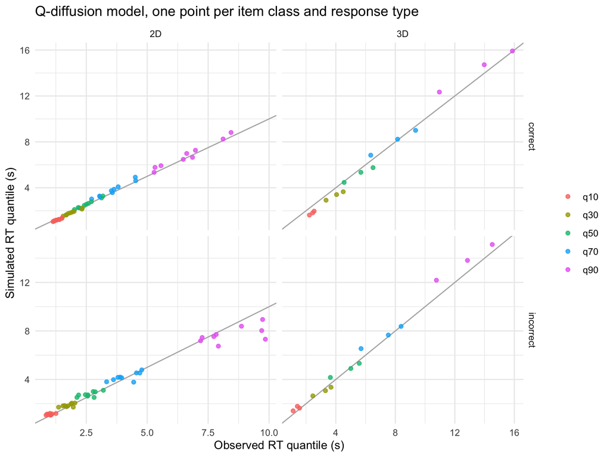

```r
ppc_long |> filter(model == "Q, Ter by 2D/3D") |>
  ggplot(aes(o, s, colour = q)) + geom_abline(colour = "grey70") + geom_point(alpha = .8) +
  facet_grid(resp ~ group, scales = "free") +
  labs(x = "Observed RT quantile (s)", y = "Simulated RT quantile (s)", colour = NULL,
       title = "Q-diffusion model, one point per item class and response type")
```

```r
ppc_long |> summarise(bias = weighted.mean(s - o, n), .by = c(model, group, resp, q)) |>
  pivot_wider(names_from = q, values_from = bias) |> arrange(model, group, resp) |> mutate(across(where(is.numeric), \(z) round(z, 2)))
```

| model | group | resp | q10 | q30 | q50 | q70 | q90 |
| --- | --- | --- | --- | --- | --- | --- | --- |
| D, Ter by 2D/3D | 2D | correct | -0.10 | 0.01 | 0.18 | 0.35 | 0.22 |
| D, Ter by 2D/3D | 2D | incorrect | 0.07 | 0.09 | 0.11 | 0.15 | -0.40 |
| D, Ter by 2D/3D | 3D | correct | -0.60 | -0.67 | -0.50 | -0.15 | 0.32 |
| D, Ter by 2D/3D | 3D | incorrect | 0.27 | -0.08 | 0.12 | 0.44 | 1.29 |
| Q, Ter by 2D/3D | 2D | correct | -0.12 | -0.06 | 0.06 | 0.22 | 0.19 |
| Q, Ter by 2D/3D | 2D | incorrect | 0.06 | 0.10 | 0.12 | 0.13 | -0.52 |
| Q, Ter by 2D/3D | 3D | correct | -0.60 | -0.62 | -0.37 | 0.10 | 0.77 |
| Q, Ter by 2D/3D | 3D | incorrect | 0.24 | -0.15 | 0.02 | 0.28 | 0.96 |
| Q, Ter per class | 2D | correct | -0.11 | -0.05 | 0.07 | 0.22 | 0.20 |
| Q, Ter per class | 2D | incorrect | 0.05 | 0.09 | 0.11 | 0.12 | -0.50 |

[output cut: 2 more lines]

(Predicted minus observed, in seconds.) Reading the Q model:

- **2D classes fit well.** Quantiles are within about 0.1–0.2 s of the data for correct responses. The one clear miss is that the long right tail of incorrect responses is under-predicted (90th percentile 0.5 s too fast).
- **3D classes do not fit well.** The model spreads the 3D RT distribution too widely: for correct responses the fast quantiles are about 0.6 s too fast and the 90th percentile about 0.8 s too slow. The data have a higher floor and a narrower spread than a Wiener process with these parameters can produce. A single non-decision time per class cannot absorb that (the per-class $T_{er}$ model has the same pattern), which is the usual sign that non-decision time varies from trial to trial, or that some responses are contaminant guesses. diffIRT has neither.
- **Accuracy.** The Q model over-predicts accuracy for the hard 2D classes by 4–7 points (duck 160$^\circ$: .845 vs .774 observed) and is accurate for the easy and 3D classes. The D model gets accuracy nearly right (mean absolute error .010 vs .030) but is worse on the RT quantiles, especially the middle ones (median RMSE 0.35 s vs 0.26 s). This matches what the 2PL comparison showed: the multiplicative Q structure gives up some accuracy fit to fit RT.

```r
a_o <- ppc$observed$acc
tibble(item_uid = a_o$item_uid, observed = a_o$acc,
       `Q` = ppc$models[[1]]$acc$acc[match(a_o$item_uid, ppc$models[[1]]$acc$item_uid)],
       `Q, Ter per class` = ppc$models[[2]]$acc$acc[match(a_o$item_uid, ppc$models[[2]]$acc$item_uid)],
       `D` = ppc$models[[3]]$acc$acc[match(a_o$item_uid, ppc$models[[3]]$acc$item_uid)]) |>
  arrange(item_uid) |> mutate(across(-item_uid, f3))
```

| item_uid | observed | Q | Q, Ter per class | D |
| --- | --- | --- | --- | --- |
| mrot_2d_duck_040 | 0.916 | 0.924 | 0.923 | 0.927 |
| mrot_2d_duck_080 | 0.872 | 0.902 | 0.902 | 0.883 |
| mrot_2d_duck_120 | 0.822 | 0.873 | 0.868 | 0.837 |
| mrot_2d_duck_160 | 0.774 | 0.845 | 0.843 | 0.796 |
| mrot_2d_rabbit_020 | 0.945 | 0.916 | 0.912 | 0.942 |
| mrot_2d_rabbit_040 | 0.935 | 0.924 | 0.921 | 0.937 |
| mrot_2d_rabbit_080 | 0.887 | 0.902 | 0.899 | 0.899 |
| mrot_2d_rabbit_120 | 0.814 | 0.851 | 0.851 | 0.825 |
| mrot_2d_rabbit_160 | 0.755 | 0.813 | 0.811 | 0.763 |
| mrot_3d_shape_040 | 0.782 | 0.792 | 0.786 | 0.785 |

[output cut: 2 more lines]

Errors versus correct responses. In a Wiener model with an unbiased start, correct and incorrect responses have the same mean decision time for a given person and item. Differences in the pooled data come only from mixing over people. The observed pattern is that errors are slower than correct responses for easy 2D items and faster for the 3D items (by 0.7–1.0 s). The Q model reproduces the sign of both effects but under-predicts the 3D size, which again points to fast guesses in the 3D errors.

```r
d_err <- \(b) b |> pivot_wider(names_from = correct, values_from = mean_rt, names_prefix = "c") |> mutate(diff = c0 - c1) |> select(item_uid, diff)
reduce(c(list(d_err(ppc$observed$by) |> rename(observed = diff)),
         map(ppc$models, \(r) d_err(r$acc_by) |> rename(!!r$name := diff))), left_join, by = "item_uid") |>
  mutate(across(-item_uid, \(z) round(z, 2)))
```

| item_uid | observed | Q, Ter by 2D/3D | Q, Ter per class | D, Ter by 2D/3D |
| --- | --- | --- | --- | --- |
| mrot_2d_duck_040 | 0.59 | 0.56 | 0.66 | 0.19 |
| mrot_2d_duck_080 | 0.23 | 0.41 | 0.44 | 0.34 |
| mrot_2d_duck_120 | 0.10 | 0.15 | 0.16 | 0.10 |
| mrot_2d_duck_160 | -0.04 | -0.08 | -0.11 | -0.21 |
| mrot_2d_rabbit_020 | 1.67 | 0.55 | 0.56 | 0.36 |
| mrot_2d_rabbit_040 | 0.60 | 0.67 | 0.60 | 0.29 |
| mrot_2d_rabbit_080 | 0.87 | 0.47 | 0.58 | 0.36 |
| mrot_2d_rabbit_120 | 0.13 | 0.09 | -0.03 | -0.02 |
| mrot_2d_rabbit_160 | 0.26 | -0.11 | -0.15 | 0.02 |
| mrot_3d_shape_040 | -0.66 | -0.26 | -0.29 | 0.08 |

[output cut: 2 more lines]

Free $T_{er}$ per class improves the likelihood slightly ($-2LL$ 253,334 vs 253,391, AIC lower, BIC higher) and fits only a little better on the RT quantiles. The 3D $T_{er}$ values then fall with angle (0.23, 0.15, 0.07 s), which is the model compensating for the misfit, not a result.

# 10. Does the response time add information?

The check is whether the extra information in the RT makes the person scores more reliable or more valid than accuracy alone (`07_rt_information.R`). Each run’s trials are split at random into two halves (balanced within person, 1,052 runs with at least 16 trials, 20 random splits). Each half is scored with the 2PL (item parameters fixed at the paper’s, accuracy only, $N(0,1)$ prior) and with the Q-diffusion model (item parameters fixed at the full fit, accuracy and RT). Both see the same trials.

```r
ri <- read_rds(here("models/diffirt_rt_information.rds"))
ri$reliability |> mutate(score = recode(score, irt = "2PL theta (accuracy only)", q_theta = "Q log theta (accuracy + RT)",
                                        q_gamma = "Q log gamma", acc = "proportion correct", mlrt = "mean log RT")) |>
  mutate(across(where(is.numeric), \(z) round(z, 3)))
```

| score | r_half | sd_over_splits | spearman_brown |
| --- | --- | --- | --- |
| 2PL theta (accuracy only) | 0.817 | 0.007 | 0.900 |
| Q log theta (accuracy + RT) | 0.827 | 0.006 | 0.906 |
| Q log gamma | 0.832 | 0.009 | 0.909 |
| proportion correct | 0.590 | 0.012 | 0.742 |
| mean log RT | 0.813 | 0.011 | 0.897 |

- **Reliability is the same.** Split-half reliability is .90 (Spearman-Brown) for both the 2PL and the Q drift score. Using the RT does not make the person estimate more reliable, at this test length (about 21 trials per half).
- **The added prediction is small.** When the score from one half predicts the 2PL ability in the other half, adding the Q drift and boundary scores to the 2PL score raises $R^2$ from .668 to .681 (and mean log RT alone to .671). Predicting the other half’s raw accuracy goes from .430 to .456. In the other direction (predicting Q drift from the other half) the 2PL adds .005.
- **Cross-prediction does not favour the diffusion score.** The Q drift score from one half predicts the other half’s 2PL ability less well (r = .76) than the 2PL score does (.82).

```r
ri$retest |> mutate(across(where(is.numeric), \(z) round(z, 2)))
```

| measure | r | lo | hi |
| --- | --- | --- | --- |
| 2PL stability | 0.70 | 0.61 | 0.78 |
| Q theta stability | 0.70 | 0.60 | 0.79 |
| Q gamma stability | 0.41 | 0.25 | 0.57 |
| Q theta1 -> 2PL2 | 0.61 | 0.48 | 0.73 |
| 2PL1 -> Q theta2 | 0.69 | 0.60 | 0.77 |
| 2PL stability, age-adjusted | 0.62 | 0.52 | 0.72 |
| Q theta stability, age-adjusted | 0.52 | 0.39 | 0.64 |

Test-retest, for the 121 children with two runs at least three months apart (median gap 0.3 years): stability is .70 for both the 2PL ability and the Q drift (CIs are wide). Adjusting for age at each run, the stability falls to .62 (2PL) and .52 (Q drift), and the intervals overlap. The $\gamma$ score is stable only at .41, which is consistent with it being a run-level response-time level that moves with testing conditions. None of this shows an advantage for the RT-based score.

```r
# validity against age: does the Q score add to the 2PL score in explaining age?
age_r2 <- c(`2PL` = summary(lm(age ~ theta_irt, persons))$r.squared,
            `+ Q log theta` = summary(lm(age ~ theta_irt + log(theta), persons))$r.squared,
            `+ Q log theta and log gamma` = summary(lm(age ~ theta_irt + log(theta) + log(gamma), persons))$r.squared)
round(age_r2, 3)
```

```
##                         2PL               + Q log theta
##                       0.130                       0.197
## + Q log theta and log gamma
##                       0.207
```

Against age, adding the Q scores raises $R^2$ for age from 0.13 to 0.21. That is a hint that the RT carries developmental signal, but speeding up with age is expected for any task, so it does not show a better measure of mental rotation.

**Conclusion.** For these data the RT adds little over accuracy for measuring ability: equal reliability, a gain of one to three points of explained variance in cross-half prediction, and no gain in retest stability. The diffusion model is still useful for describing how responses are produced (drift versus response level, differences in the speed of the sexes) but it does not justify replacing the 2PL as the paper’s ability score.

# 11. Summary and caveats

- The recipe is: build person-by-item matrices, constrain parameters within item classes, trim responses faster than 0.5 s, and run `diffIRT(model = "Q")` with a couple of quadrature settings. The optimised build fits all 1,158 assessments in a few seconds.
- The difficulty-like parameter $v_i$ orders the item classes like the 2PL difficulty ($r = .96$; $.89$ within the 2D classes). The 2PL discrimination does not carry over to a Q-diffusion parameter, because difficulty and slope are not separate parameters in the Q model, and the two disagree in direction (section 5).
- The Q-diffusion person drift $\theta$ is highly correlated with the 2PL ability and a bit more strongly related to age ($R^2$ .20 vs .13 with a spline in age). The 2PL predicts accuracy slightly better, and the Q model also predicts the class mean RTs reasonably well.
- The paper’s age, sex and site results carry over to the diffusion drift score (section 7): same age trend, no sex or age $\times$ sex effect on ability, and the same site ordering. The boys-are-faster result shows up in $\gamma$, which is mostly a response-time level parameter (r = .89 with mean log RT) and is not a separate caution trait.
- The D (additive) variant fits as easily as Q but much worse overall ($-2LL$ about 1,900 higher). It matches the 2PL difficulties more closely (r = .99) and predicts accuracy better than Q, but its RT quantiles are worse (section 8).
- RT fit (section 9): good for the 2D classes. For the 3D classes a single Wiener process spreads the RT distribution too widely, and the Q model overpredicts accuracy on the hard 2D classes by 4–7 points. A trial-to-trial varying non-decision time or a contaminant (fast guess) component would be the natural next models; diffIRT has neither.
- RT adds little for measuring ability (section 10): equal split-half reliability (.90), one to three points more explained variance in cross-half prediction, no better test-retest stability. The diffusion model describes how responses are produced and gives a speed/response-level parameter, but it does not justify replacing the 2PL.
- Caveats: standard errors are conditional on the model being right (and the RT misfit above shows it is not exactly); 3D non-decision time is weakly identified; the section-5 comparison is across 12 classes; person scores are EAP estimates and the fit checks are in-sample; the optimised and the original diffIRT were never compared on the same fit, because the original never finished; and the retest sample is only about 120 children.

```
## [1] "1.5"
```